# IP_deepxde slides

Individual Project : Falkner Skan Formulation C

### PRANAY KANSAL(200700)

#### 1. Introduction

The objective was solving Falkner Skan Equation Formulation-C through machine learning. In this, physics informed extreme learning machine and physics informed neural network to solve the ODE eq as well as the boundary conditions. The ODE for the problem is :-

and  
τ-du/dη=0

The Boundary Conditions of are:- At the (η= 0):

u(0) = 0

At the far field (as η approaches infinity):

u(∞) = 1

the velocity at infinty was 5m/s (U<sub>0</sub>)

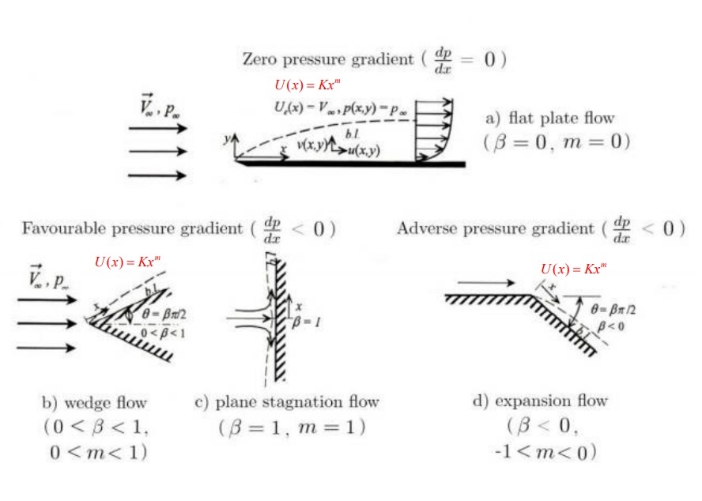

Defining ode:-

```python
beta=0                       #pi * beta/2 - angle
m=beta/(2-beta)

def pde(eta, out):
    u,tau=out[:,0:1],out[:,1:2]
    u_eta = dde.grad.jacobian(out, eta, i=0, j=0)
    tau_eta= dde.grad.jacobian(out, eta, i=1, j=0)

    term1=tau_eta/u_eta
    term1=dde.grad.jacobian(term1, eta)

    ode_1=(1/u_eta)*term1 - beta*(1-u*u)*(1/(u_eta*tau*tau))*tau_eta # + (1-2*beta)*u/tau

    ode_2=tau-u_eta

    return [ode_1,ode_2]
```

Defining the boundary conditions:-

```python
eps=0.1
geom = dde.geometry.Interval(0,5)

def boundary_b(eta,on_boundary):
    return on_boundary and np.isclose(eta[0], 0)
def boundary_t(eta,on_boundary):
    return on_boundary and np.isclose(eta[0], 5)

bc_1 = dde.DirichletBC(geom, lambda X: 0, boundary_b, component=0)
bc_2 = dde.DirichletBC(geom, lambda X: 1, boundary_t, component=0)
bc_3 = dde.DirichletBC(geom, lambda X: eps, boundary_t, component=1)
#bc_4 = dde.OperatorBC(geom, lambda X, y: dde.grad.hessian(y,X) - 0, boundary_r)
#bc_4 = dde.OperatorBC(geom, hessian_r, boundary_r)

bc = [bc_1, bc_2, bc_3]

data = dde.data.PDE(geom, pde, bc, num_domain=60, num_boundary= 2, num_test=40)
```

Defining our model :-

```python
layer_size = [1] + [50] * 3 + [2]
activation = 'swish'
initializer = 'Glorot uniform'
net = dde.nn.FNN(layer_size, activation, initializer)
model = dde.Model(data, net)
model.compile("adam", lr=1e-3, decay = ("inverse time", 1000, 0.3))
```

```
Compiling model...
Building feed-forward neural network...
'build' took 0.069572 s
```

```
'compile' took 2.246604 s
```

Training the model:-

```python
losshistory, train_state = model.train(iterations=10000)
```

```
Training model...

0         [nan, 9.05e-03, 0.00e+00, 8.44e-01, 7.40e-02]         [2.86e+10, 9.02e-03, 0.00e+00, 8.44e-01, 7.40e-02]    []

Best model at step 0:
  train loss: inf
  test loss: inf
  test metric:

'train' took 2.202262 s
```

```python
dde.saveplot(losshistory, train_state, issave=True, isplot=True)
```

[output not shown]